# Risk Factor Analysis

## Outcome Variable

**Outcome Variable:** stunted

## Predictor Variables

**Intervention Variable:** cleanck

**Adjustment Set:**

unadjusted

## Stratifying Variables

The analysis was stratified on these variable(s):

- agecat
- studyid
- country

## Data Summary

| agecat | studyid | country | cleanck | stunted | n_cell | n |
| --- | --- | --- | --- | --- | --- | --- |
| Birth | CMC-V-BCS-2002 | INDIA | 1 | 0 | 35 | 92 |
| Birth | CMC-V-BCS-2002 | INDIA | 1 | 1 | 4 | 92 |
| Birth | CMC-V-BCS-2002 | INDIA | 0 | 0 | 40 | 92 |
| Birth | CMC-V-BCS-2002 | INDIA | 0 | 1 | 13 | 92 |
| Birth | GMS-Nepal | NEPAL | 1 | 0 | 9 | 621 |
| Birth | GMS-Nepal | NEPAL | 1 | 1 | 0 | 621 |
| Birth | GMS-Nepal | NEPAL | 0 | 0 | 506 | 621 |
| Birth | GMS-Nepal | NEPAL | 0 | 1 | 106 | 621 |
| Birth | IRC | INDIA | 1 | 0 | 197 | 378 |
| Birth | IRC | INDIA | 1 | 1 | 21 | 378 |
| Birth | IRC | INDIA | 0 | 0 | 138 | 378 |
| Birth | IRC | INDIA | 0 | 1 | 22 | 378 |
| Birth | MAL-ED | PERU | 1 | 0 | 1 | 2 |
| Birth | MAL-ED | PERU | 1 | 1 | 0 | 2 |
| Birth | MAL-ED | PERU | 0 | 0 | 1 | 2 |
| Birth | MAL-ED | PERU | 0 | 1 | 0 | 2 |
| Birth | NIH-Crypto | BANGLADESH | 1 | 0 | 301 | 561 |
| Birth | NIH-Crypto | BANGLADESH | 1 | 1 | 44 | 561 |
| Birth | NIH-Crypto | BANGLADESH | 0 | 0 | 183 | 561 |
| Birth | NIH-Crypto | BANGLADESH | 0 | 1 | 33 | 561 |
| Birth | PROVIDE | BANGLADESH | 1 | 0 | 400 | 539 |
| Birth | PROVIDE | BANGLADESH | 1 | 1 | 38 | 539 |
| Birth | PROVIDE | BANGLADESH | 0 | 0 | 91 | 539 |
| Birth | PROVIDE | BANGLADESH | 0 | 1 | 10 | 539 |
| 6 months | CMC-V-BCS-2002 | INDIA | 1 | 0 | 123 | 369 |
| 6 months | CMC-V-BCS-2002 | INDIA | 1 | 1 | 40 | 369 |
| 6 months | CMC-V-BCS-2002 | INDIA | 0 | 0 | 135 | 369 |
| 6 months | CMC-V-BCS-2002 | INDIA | 0 | 1 | 71 | 369 |
| 6 months | GMS-Nepal | NEPAL | 1 | 0 | 8 | 505 |
| 6 months | GMS-Nepal | NEPAL | 1 | 1 | 0 | 505 |
| 6 months | GMS-Nepal | NEPAL | 0 | 0 | 388 | 505 |
| 6 months | GMS-Nepal | NEPAL | 0 | 1 | 109 | 505 |
| 6 months | IRC | INDIA | 1 | 0 | 181 | 398 |
| 6 months | IRC | INDIA | 1 | 1 | 49 | 398 |
| 6 months | IRC | INDIA | 0 | 0 | 119 | 398 |
| 6 months | IRC | INDIA | 0 | 1 | 49 | 398 |
| 6 months | MAL-ED | SOUTH AFRICA | 1 | 0 | 1 | 1 |
| 6 months | MAL-ED | SOUTH AFRICA | 1 | 1 | 0 | 1 |
| 6 months | MAL-ED | SOUTH AFRICA | 0 | 0 | 0 | 1 |
| 6 months | MAL-ED | SOUTH AFRICA | 0 | 1 | 0 | 1 |
| 6 months | NIH-Crypto | BANGLADESH | 1 | 0 | 264 | 545 |
| 6 months | NIH-Crypto | BANGLADESH | 1 | 1 | 65 | 545 |
| 6 months | NIH-Crypto | BANGLADESH | 0 | 0 | 179 | 545 |
| 6 months | NIH-Crypto | BANGLADESH | 0 | 1 | 37 | 545 |
| 6 months | PROVIDE | BANGLADESH | 1 | 0 | 429 | 604 |
| 6 months | PROVIDE | BANGLADESH | 1 | 1 | 69 | 604 |
| 6 months | PROVIDE | BANGLADESH | 0 | 0 | 79 | 604 |
| 6 months | PROVIDE | BANGLADESH | 0 | 1 | 27 | 604 |
| 24 months | CMC-V-BCS-2002 | INDIA | 1 | 0 | 67 | 371 |
| 24 months | CMC-V-BCS-2002 | INDIA | 1 | 1 | 96 | 371 |
| 24 months | CMC-V-BCS-2002 | INDIA | 0 | 0 | 38 | 371 |
| 24 months | CMC-V-BCS-2002 | INDIA | 0 | 1 | 170 | 371 |
| 24 months | GMS-Nepal | NEPAL | 1 | 0 | 5 | 435 |
| 24 months | GMS-Nepal | NEPAL | 1 | 1 | 0 | 435 |
| 24 months | GMS-Nepal | NEPAL | 0 | 0 | 232 | 435 |
| 24 months | GMS-Nepal | NEPAL | 0 | 1 | 198 | 435 |
| 24 months | IRC | INDIA | 1 | 0 | 142 | 400 |
| 24 months | IRC | INDIA | 1 | 1 | 89 | 400 |
| 24 months | IRC | INDIA | 0 | 0 | 89 | 400 |
| 24 months | IRC | INDIA | 0 | 1 | 80 | 400 |
| 24 months | MAL-ED | SOUTH AFRICA | 1 | 0 | 1 | 1 |
| 24 months | MAL-ED | SOUTH AFRICA | 1 | 1 | 0 | 1 |
| 24 months | MAL-ED | SOUTH AFRICA | 0 | 0 | 0 | 1 |
| 24 months | MAL-ED | SOUTH AFRICA | 0 | 1 | 0 | 1 |
| 24 months | NIH-Crypto | BANGLADESH | 1 | 0 | 156 | 410 |
| 24 months | NIH-Crypto | BANGLADESH | 1 | 1 | 43 | 410 |
| 24 months | NIH-Crypto | BANGLADESH | 0 | 0 | 167 | 410 |
| 24 months | NIH-Crypto | BANGLADESH | 0 | 1 | 44 | 410 |
| 24 months | PROVIDE | BANGLADESH | 1 | 0 | 338 | 578 |
| 24 months | PROVIDE | BANGLADESH | 1 | 1 | 141 | 578 |
| 24 months | PROVIDE | BANGLADESH | 0 | 0 | 50 | 578 |
| 24 months | PROVIDE | BANGLADESH | 0 | 1 | 49 | 578 |

The following strata were considered:

- agecat: 24 months, studyid: CMC-V-BCS-2002, country: INDIA
- agecat: 24 months, studyid: GMS-Nepal, country: NEPAL
- agecat: 24 months, studyid: IRC, country: INDIA
- agecat: 24 months, studyid: MAL-ED, country: SOUTH AFRICA
- agecat: 24 months, studyid: NIH-Crypto, country: BANGLADESH
- agecat: 24 months, studyid: PROVIDE, country: BANGLADESH
- agecat: 6 months, studyid: CMC-V-BCS-2002, country: INDIA
- agecat: 6 months, studyid: GMS-Nepal, country: NEPAL
- agecat: 6 months, studyid: IRC, country: INDIA
- agecat: 6 months, studyid: MAL-ED, country: SOUTH AFRICA
- agecat: 6 months, studyid: NIH-Crypto, country: BANGLADESH
- agecat: 6 months, studyid: PROVIDE, country: BANGLADESH
- agecat: Birth, studyid: CMC-V-BCS-2002, country: INDIA
- agecat: Birth, studyid: GMS-Nepal, country: NEPAL
- agecat: Birth, studyid: IRC, country: INDIA
- agecat: Birth, studyid: MAL-ED, country: PERU
- agecat: Birth, studyid: NIH-Crypto, country: BANGLADESH
- agecat: Birth, studyid: PROVIDE, country: BANGLADESH

### Dropped Strata

Some strata were dropped due to rare outcomes:

- agecat: Birth, studyid: CMC-V-BCS-2002, country: INDIA
- agecat: Birth, studyid: GMS-Nepal, country: NEPAL
- agecat: Birth, studyid: MAL-ED, country: PERU
- agecat: 6 months, studyid: GMS-Nepal, country: NEPAL
- agecat: 6 months, studyid: MAL-ED, country: SOUTH AFRICA
- agecat: 24 months, studyid: GMS-Nepal, country: NEPAL
- agecat: 24 months, studyid: MAL-ED, country: SOUTH AFRICA

## Methods Detail

We’re interested in the causal parameters $E[Y_a]$ for all values of $a \in \mathcal{A}$. These parameters represent the mean outcome if, possibly contrary to fact, we intervened to set all units to have $A=a$. Under the randomization and positivity assumptions, these are identified by the statistical parameters $\psi_a=E_W[E_{Y|A,W}(Y|A=a,W)]$. In addition, we’re interested in the mean of $Y$, $E[Y]$ under no intervention (the observed mean). We will estimate these parameters by using SuperLearner to fit the relevant likelihood factors – $E_{Y|A,W}(Y|A=a,W)$ and $p(A=a|W)$, and then updating our likelihood fit using a joint TMLE.

For unadjusted analyses ($W=\{\}$), initial likelihoods were estimated using Lrnr_glm to estimate the simple $E(Y|A)$ and Lrnr_mean to estimate $p(A)$. For adjusted analyses, a small library containing Lrnr_glmnet, Lrnr_xgboost, and Lrnr_mean was used.

Having estimated these parameters, we will then use the delta method to estimate relative risks and attributable risks relative to a prespecified baseline level of $A$.

# Results Detail

## Results Plots

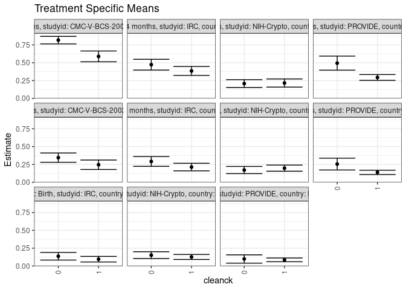

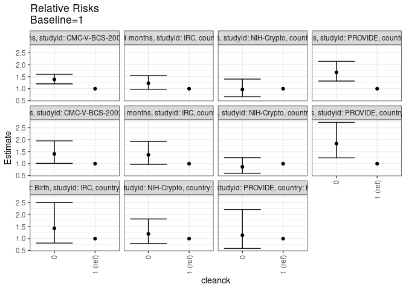

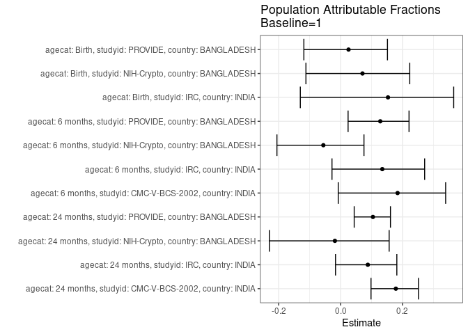

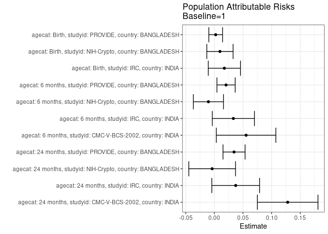

## Results Table

### Parameter: TSM

| agecat | studyid | country | intervention_level | baseline_level | estimate | ci_lower | ci_upper |
| --- | --- | --- | --- | --- | --- | --- | --- |
| Birth | IRC | INDIA | 1 | NA | 0.0963303 | 0.0571126 | 0.1355479 |
| Birth | IRC | INDIA | 0 | NA | 0.1375000 | 0.0840689 | 0.1909311 |
| Birth | NIH-Crypto | BANGLADESH | 1 | NA | 0.1275362 | 0.0923059 | 0.1627665 |
| Birth | NIH-Crypto | BANGLADESH | 0 | NA | 0.1527778 | 0.1047561 | 0.2007995 |
| Birth | PROVIDE | BANGLADESH | 1 | NA | 0.0867580 | 0.0603727 | 0.1131433 |
| Birth | PROVIDE | BANGLADESH | 0 | NA | 0.0990099 | 0.0407070 | 0.1573128 |
| 6 months | CMC-V-BCS-2002 | INDIA | 1 | NA | 0.2453988 | 0.1792475 | 0.3115501 |
| 6 months | CMC-V-BCS-2002 | INDIA | 0 | NA | 0.3446602 | 0.2796723 | 0.4096481 |
| 6 months | IRC | INDIA | 1 | NA | 0.2130435 | 0.1600601 | 0.2660269 |
| 6 months | IRC | INDIA | 0 | NA | 0.2916667 | 0.2228487 | 0.3604847 |
| 6 months | NIH-Crypto | BANGLADESH | 1 | NA | 0.1975684 | 0.1545047 | 0.2406321 |
| 6 months | NIH-Crypto | BANGLADESH | 0 | NA | 0.1712963 | 0.1210049 | 0.2215877 |
| 6 months | PROVIDE | BANGLADESH | 1 | NA | 0.1385542 | 0.1081862 | 0.1689223 |
| 6 months | PROVIDE | BANGLADESH | 0 | NA | 0.2547170 | 0.1717043 | 0.3377297 |
| 24 months | CMC-V-BCS-2002 | INDIA | 1 | NA | 0.5889571 | 0.5133215 | 0.6645926 |
| 24 months | CMC-V-BCS-2002 | INDIA | 0 | NA | 0.8173077 | 0.7647235 | 0.8698919 |
| 24 months | IRC | INDIA | 1 | NA | 0.3852814 | 0.3224448 | 0.4481180 |
| 24 months | IRC | INDIA | 0 | NA | 0.4733728 | 0.3980022 | 0.5487433 |
| 24 months | NIH-Crypto | BANGLADESH | 1 | NA | 0.2160804 | 0.1588278 | 0.2733330 |
| 24 months | NIH-Crypto | BANGLADESH | 0 | NA | 0.2085308 | 0.1536476 | 0.2634140 |
| 24 months | PROVIDE | BANGLADESH | 1 | NA | 0.2943633 | 0.2535136 | 0.3352129 |
| 24 months | PROVIDE | BANGLADESH | 0 | NA | 0.4949495 | 0.3963773 | 0.5935217 |

### Parameter: E(Y)

| agecat | studyid | country | intervention_level | baseline_level | estimate | ci_lower | ci_upper |
| --- | --- | --- | --- | --- | --- | --- | --- |
| Birth | IRC | INDIA | NA | NA | 0.1137566 | 0.0817056 | 0.1458077 |
| Birth | NIH-Crypto | BANGLADESH | NA | NA | 0.1372549 | 0.1087540 | 0.1657558 |
| Birth | PROVIDE | BANGLADESH | NA | NA | 0.0890538 | 0.0649864 | 0.1131212 |
| 6 months | CMC-V-BCS-2002 | INDIA | NA | NA | 0.3008130 | 0.2539566 | 0.3476694 |
| 6 months | IRC | INDIA | NA | NA | 0.2462312 | 0.2038529 | 0.2886094 |
| 6 months | NIH-Crypto | BANGLADESH | NA | NA | 0.1871560 | 0.1543801 | 0.2199318 |
| 6 months | PROVIDE | BANGLADESH | NA | NA | 0.1589404 | 0.1297581 | 0.1881227 |
| 24 months | CMC-V-BCS-2002 | INDIA | NA | NA | 0.7169811 | 0.6710815 | 0.7628807 |
| 24 months | IRC | INDIA | NA | NA | 0.4225000 | 0.3740325 | 0.4709675 |
| 24 months | NIH-Crypto | BANGLADESH | NA | NA | 0.2121951 | 0.1725707 | 0.2518196 |
| 24 months | PROVIDE | BANGLADESH | NA | NA | 0.3287197 | 0.2903909 | 0.3670485 |

### Parameter: RR

| agecat | studyid | country | intervention_level | baseline_level | estimate | ci_lower | ci_upper |
| --- | --- | --- | --- | --- | --- | --- | --- |
| Birth | IRC | INDIA | 1 | 1 | 1.0000000 | 1.0000000 | 1.000000 |
| Birth | IRC | INDIA | 0 | 1 | 1.4273810 | 0.8130518 | 2.505888 |
| Birth | NIH-Crypto | BANGLADESH | 1 | 1 | 1.0000000 | 1.0000000 | 1.000000 |
| Birth | NIH-Crypto | BANGLADESH | 0 | 1 | 1.1979167 | 0.7883024 | 1.820373 |
| Birth | PROVIDE | BANGLADESH | 1 | 1 | 1.0000000 | 1.0000000 | 1.000000 |
| Birth | PROVIDE | BANGLADESH | 0 | 1 | 1.1412194 | 0.5882167 | 2.214119 |
| 6 months | CMC-V-BCS-2002 | INDIA | 1 | 1 | 1.0000000 | 1.0000000 | 1.000000 |
| 6 months | CMC-V-BCS-2002 | INDIA | 0 | 1 | 1.4044903 | 1.0107643 | 1.951585 |
| 6 months | IRC | INDIA | 1 | 1 | 1.0000000 | 1.0000000 | 1.000000 |
| 6 months | IRC | INDIA | 0 | 1 | 1.3690476 | 0.9717089 | 1.928861 |
| 6 months | NIH-Crypto | BANGLADESH | 1 | 1 | 1.0000000 | 1.0000000 | 1.000000 |
| 6 months | NIH-Crypto | BANGLADESH | 0 | 1 | 0.8670228 | 0.6014872 | 1.249783 |
| 6 months | PROVIDE | BANGLADESH | 1 | 1 | 1.0000000 | 1.0000000 | 1.000000 |
| 6 months | PROVIDE | BANGLADESH | 0 | 1 | 1.8383921 | 1.2412803 | 2.722742 |
| 24 months | CMC-V-BCS-2002 | INDIA | 1 | 1 | 1.0000000 | 1.0000000 | 1.000000 |
| 24 months | CMC-V-BCS-2002 | INDIA | 0 | 1 | 1.3877204 | 1.2020453 | 1.602076 |
| 24 months | IRC | INDIA | 1 | 1 | 1.0000000 | 1.0000000 | 1.000000 |
| 24 months | IRC | INDIA | 0 | 1 | 1.2286417 | 0.9782237 | 1.543165 |
| 24 months | NIH-Crypto | BANGLADESH | 1 | 1 | 1.0000000 | 1.0000000 | 1.000000 |
| 24 months | NIH-Crypto | BANGLADESH | 0 | 1 | 0.9650612 | 0.6642983 | 1.401995 |
| 24 months | PROVIDE | BANGLADESH | 1 | 1 | 1.0000000 | 1.0000000 | 1.000000 |
| 24 months | PROVIDE | BANGLADESH | 0 | 1 | 1.6814242 | 1.3190404 | 2.143367 |

### Parameter: PAR

| agecat | studyid | country | intervention_level | baseline_level | estimate | ci_lower | ci_upper |
| --- | --- | --- | --- | --- | --- | --- | --- |
| Birth | IRC | INDIA | 1 | NA | 0.0174263 | -0.0107033 | 0.0455560 |
| Birth | NIH-Crypto | BANGLADESH | 1 | NA | 0.0097187 | -0.0132356 | 0.0326730 |
| Birth | PROVIDE | BANGLADESH | 1 | NA | 0.0022958 | -0.0097027 | 0.0142943 |
| 6 months | CMC-V-BCS-2002 | INDIA | 1 | NA | 0.0554142 | 0.0034002 | 0.1074283 |
| 6 months | IRC | INDIA | 1 | NA | 0.0331877 | -0.0036717 | 0.0700470 |
| 6 months | NIH-Crypto | BANGLADESH | 1 | NA | -0.0104124 | -0.0366755 | 0.0158506 |
| 6 months | PROVIDE | BANGLADESH | 1 | NA | 0.0203862 | 0.0044776 | 0.0362947 |
| 24 months | CMC-V-BCS-2002 | INDIA | 1 | NA | 0.1280241 | 0.0751028 | 0.1809454 |
| 24 months | IRC | INDIA | 1 | NA | 0.0372186 | -0.0044598 | 0.0788971 |
| 24 months | NIH-Crypto | BANGLADESH | 1 | NA | -0.0038853 | -0.0447024 | 0.0369318 |
| 24 months | PROVIDE | BANGLADESH | 1 | NA | 0.0343565 | 0.0150684 | 0.0536445 |

### Parameter: PAF

| agecat | studyid | country | intervention_level | baseline_level | estimate | ci_lower | ci_upper |
| --- | --- | --- | --- | --- | --- | --- | --- |
| Birth | IRC | INDIA | 1 | NA | 0.1531897 | -0.1300159 | 0.3654180 |
| Birth | NIH-Crypto | BANGLADESH | 1 | NA | 0.0708075 | -0.1118805 | 0.2234788 |
| Birth | PROVIDE | BANGLADESH | 1 | NA | 0.0257801 | -0.1185472 | 0.1514847 |
| 6 months | CMC-V-BCS-2002 | INDIA | 1 | NA | 0.1842149 | -0.0075095 | 0.3394550 |
| 6 months | IRC | INDIA | 1 | NA | 0.1347826 | -0.0277102 | 0.2715835 |
| 6 months | NIH-Crypto | BANGLADESH | 1 | NA | -0.0556350 | -0.2055179 | 0.0756128 |
| 6 months | PROVIDE | BANGLADESH | 1 | NA | 0.1282631 | 0.0243003 | 0.2211484 |
| 24 months | CMC-V-BCS-2002 | INDIA | 1 | NA | 0.1785599 | 0.0983198 | 0.2516594 |
| 24 months | IRC | INDIA | 1 | NA | 0.0880914 | -0.0162819 | 0.1817454 |
| 24 months | NIH-Crypto | BANGLADESH | 1 | NA | -0.0183099 | -0.2300178 | 0.1569592 |
| 24 months | PROVIDE | BANGLADESH | 1 | NA | 0.1045160 | 0.0440411 | 0.1611652 |